# HW 9_Onyango

Brenda Onyango

10/23/2021

## Exercise 8.1

The three common tasks in a posterior analysis: estimation, hypothesis testing, and prediction.

## Exercise 8.2

1. When only reporting the central tendency we don’t get a sense of the variability of possible values of pi. Depending on sample size the posterior credible interval could be narrow or wider (figure 8.2 in the chapter demonstrates this). Having both central tendency and variability allows us to compare different posterior models of the same prior model.
2. A 95% credible interval of (1, 3.4) means there’s a 95% posterior probability that lambda is between 1 and 3.4

## Exercise 8.3

1. Yes this could be hypothesis tested. Ho is that 40% of dogs at the park do not have a license; Ha is that more than 40% of dogs at the park do not have a license.
2. As its written this could not be hypothesis tested.
3. Yes. The null hypothesis is that 60% of people support a regulation; the alternative is that more than 60% of people support the legislation.
4. Yes. This would be a Gamma-Poisson model since we’re given a rate.

## Exercise 8.4

1. Posterior odds are the posterior probability divied by 1 minus the posterior probability and represent an updated understanding of pi,mu, or lambda that indicates how much more liklely or unlikely an hypothesis is.
2. Prior odds are the prior probability divided by 1 minus the prior probability and represent a prior understanding of pi, mu or lambda.
3. Bayes Factor is a ratio of posterior odds to prior odds and comparing Bayes Factor to 1 helps make judgements about H0 and Ha. BF = 1 means that the plausibility of Ha didn’t change in light of data; >1 means the plausibility of Ha is greater in light of data; and < 1 means the plausibility of Ha decreased in light of data.

## Exercise 8.5

1. The two types of variability in posterior predictive models are sampling variability and posterior variability. Sampling variability is variability in the data; posterior variability is the variability in possible values of pi.
2. A real life situation for posterior prediction are elections or weather forecasting.
3. Posterior predictive models are conditional on both the data and the parameter since they take into account sampling variability (data) and the posterior variability which relates to the parameter.

## Exercise 8.6

1. A 95% credible interval for π with π|y∼Beta(4,5)

First load packages needed for this exercise.

```r
library(tidyverse)
library(bayesrules)
library(rstan)
```

```r
library(bayesplot)
library(broom.mixed)
library(janitor)
library(HDInterval)
```

Next find the 95% credible interval.

```r
# 0.025th & 0.975th quantiles of the Beta(4,5) posterior
qbeta(c(0.025, 0.975), 4, 5)
```

```
## [1] 0.1570128 0.7551368
```

```r
# 0.20th & 0.80th quantiles of the Beta(4,5) posterior
qbeta(c(0.20, 0.8), 4, 5)
```

```
## [1] 0.3032258 0.5836554
```

```r
# 0.025th & 0.975th quantiles of the Gamma(1,8) posterior
qgamma(c(0.025, 0.975), 1, 8)
```

```
## [1] 0.003164726 0.461109932
```

## Exercise 8.7

```r
# 0.005th & 0.995th quantiles of the Gamma(1,5) posterior
qgamma(c(0.005, 0.995), 1, 5)
```

```
## [1] 0.001002508 1.059663473
```

```r
# 0.025th & 0.975th quantiles of the Normal(10,2^2) posterior
qnorm(c(0.025, 0.975), 10, 2)
```

```
## [1]  6.080072 13.919928
```

```r
# 0.20th & 0.80th quantiles of the Normal(-3, 1^2) posterior
qnorm(c(0.20, 0.8), -3, 1)
```

```
## [1] -3.841621 -2.158379
```

#Corrected

## Exercise 8.8

```r
# finding density between 0 and .95.
qgamma(c(0,.95), 1, 5)
```

```
## [1] 0.0000000 0.5991465
```

```r
#code from https://search.r-project.org/CRAN/refmans/HDInterval/html/hdi.html to do hdi
# for a vector:
set.seed(50)
tst <- rgamma(100, 1, 5) #randomly chose 100 for n
hdi(tst)
```

```
##       lower       upper
## 0.001737083 0.554385654
## attr(,"credMass")
## [1] 0.95
```

```r
hdi(tst, credMass=0.95)
```

```
##       lower       upper
## 0.001737083 0.554385654
## attr(,"credMass")
## [1] 0.95
```

```r
# For comparison, the symmetrical 95% CrI:
quantile(tst, c(0.025,0.975))
```

```
##        2.5%       97.5%
## 0.004218613 0.612070952
```

Next I’ll plot this to see density.

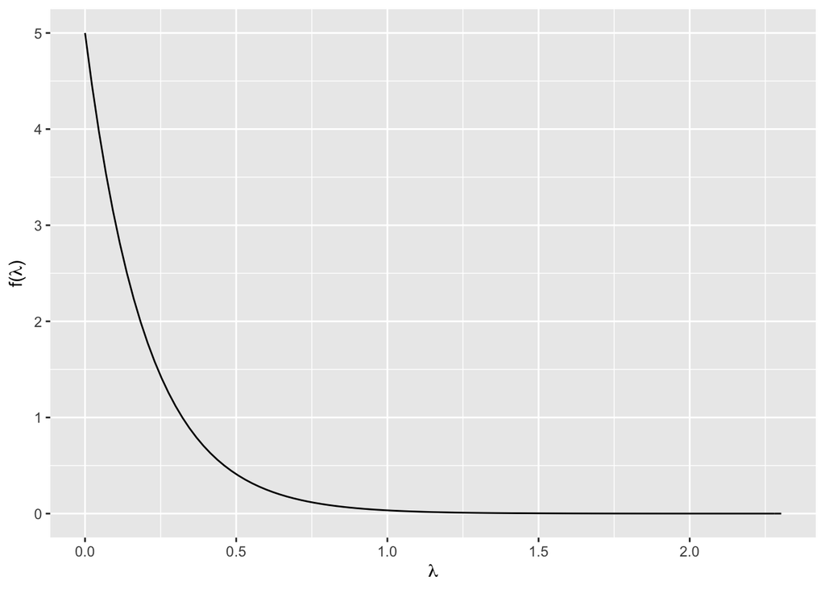

```r
plot_gamma(1,5)
```

```r
# 0.025th & 0.975th quantiles of the Gamma(1,5) posterior with the middle approach
qgamma(c(0.025, 0.975), 1, 5)
```

```
## [1] 0.005063562 0.737775891
```

```r
qnorm(c(0,.95), -13, 2)
```

```
## [1]      -Inf -9.710293
```

```r
#finding highest density interval using hdi code
set.seed(1000)
tst <- rnorm(100, -13, 2) #randomly chose 100 for n
hdi(tst)
```

```
##     lower     upper
## -16.84199  -8.88425
## attr(,"credMass")
## [1] 0.95
```

```r
hdi(tst, credMass=0.95)
```

```
##     lower     upper
## -16.84199  -8.88425
## attr(,"credMass")
## [1] 0.95
```

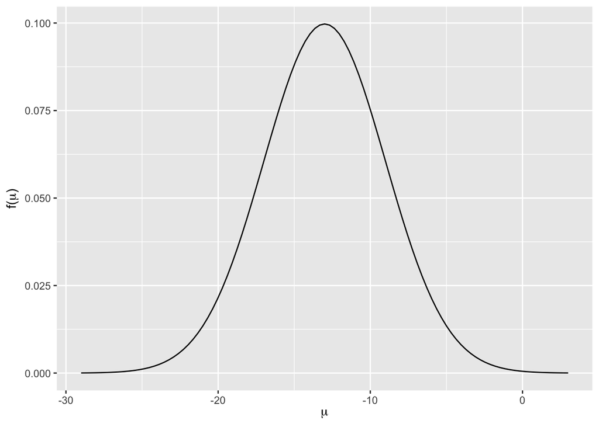

```r
plot_normal(-13,2^2)
```

5. Next the middle 95% approach.

```r
qnorm(c(0.025, 0.975), -13, 2)
```

```
## [1] -16.919928  -9.080072
```

6. The highest poster density approach gave a credible interval that ranged from 16.84 to -8.88. The middle 95% approach gave a CI between -16.919 and -9.08. They are not the same, but they are very similar. I imagine if I had a chosen a different set.seed value I may be even closer between the HDI and middle 95% approach for the normal distribution.

## Exercise 8.9

1. what is posterior probability for alternative pi > 0.4?

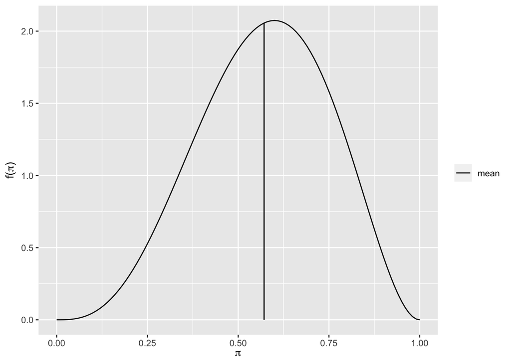

```r
#find posterior probability that pi > 0.4

post_proba <- pbeta(0.40, 4,3)
plot_beta(4,3, mean = TRUE)
```

```r
#This can be interpreted as there's roughly 17.92% posterior chance that the probability is *below* 0.40. The alternative can be found by doing 1-.1792 which is 0.8208. Looking at the plot below confirms the density of f(pi) is higher after 0.40 so the 0.8208 value makes sense.
```

2. Calculate the posterior odds and interpret.

```r
post_prob <- 0.8208
post_odds <- post_prob/(1-post_prob)
```

Post_odds = 4.58035 which means that pi is nearly 5 times more likely to be above 0.40 than to be below 0.40.

3. Calculate and interpret prior odds.

```r
#prior probability that pi is < 0.40
prior_proba <- pbeta(0.40, 1, 0.8)
prior_prob <-  1 - prior_proba #prior probability that pi is greater than 0.40
prior_odds <- prior_prob/(1-prior_prob)
```

Prior odds are 1.9809 which means the odds of pi being above .4 are about twice that of pi being below 0.40.

4. Calculate and interpret Bayes factor.

```r
BFa <- post_odds/prior_odds
```

The posterior odds of our alternate hypothesis are about 2 times higher than the prior odds which means our confidence in the alternate hypothesis increased.

5. The posterior probability (0.8208) and Bayes Factor (2.312) establish evidence in favor the the altnerate hypothesis that pi is greater than 0.40.

# Corrected

## Exercise 8.10

1. Find posterior probability that mu < 5.2 for N(5,3^2)

```r
post_probb <- pnorm(5.2, 5, 3)
```

```r
post_oddb <- post_probb/(1-post_probb)
```

The post_odds of 1.112 means that mu is about 1 times more likely to be below 5.2 than to be above 5.2.

```r
prior_probb <- pnorm(5.2, 10, 10)
prior_oddb <- prior_probb/(1-prior_probb)
```

Corrected: Prior odds are 0.4611 which means the odds of mu being below 5.2 are about half that of mu being above 5.2.

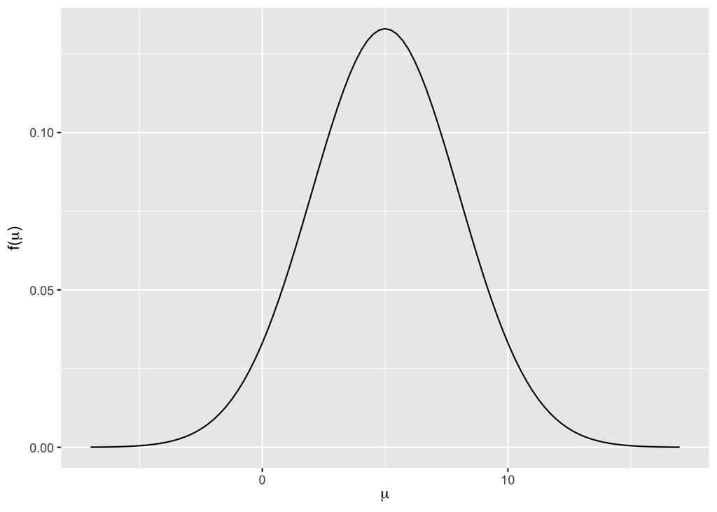

```r
plot_normal(5,3)
```

```r
#finding Bayes Factor

BFb <- post_oddb/prior_oddb
```

The Bayes Factor is 2.41188 which means posterior odds of our alternate hypothesis are about 2 times higher than the prior odds, therefore our confidence in the alternate hypothesis (mu is less than 5.2) increased.

5. The posterior probability (0.526576) and Bayes Factor (2.41188) establish evidence in favor the the alternate hypothesis that mu is less than 5.2.

#Exercise 8.14

1. The beta binomial is appropriate since we’re interested in understanding a distribution of pi.
2. I’m assuming that more people do believe in climate change than those that do not with mid level confidence so my prior is Beta(3,7) indicating more failures than successes for Y.
3. Below are plots comparing my prior to that of the author’s.

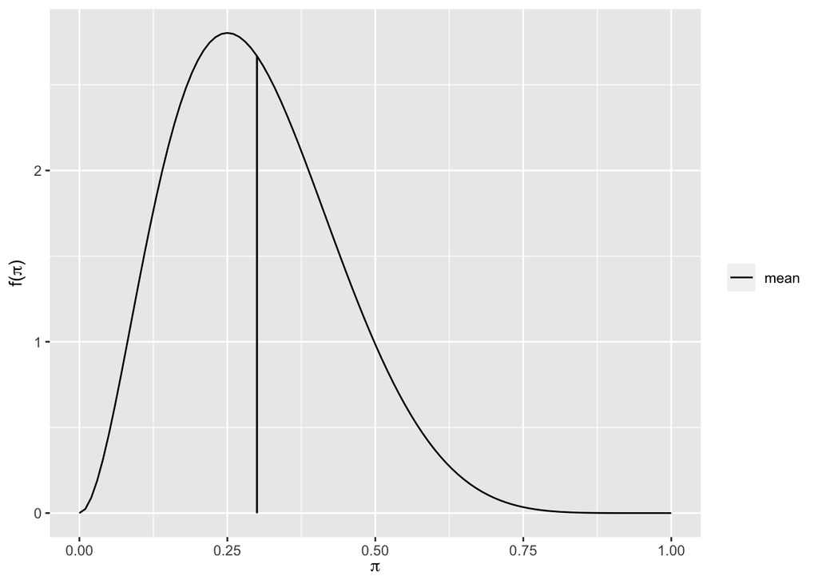

```r
plot_beta(3,7, mean = TRUE)
```

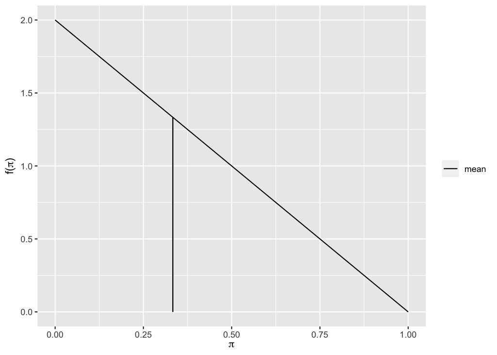

```r
plot_beta(1,2, mean = TRUE)
```

We both agree that beta > alpha meaning more people believe in climate change than not but the author’s distribution shows more variability than mine which means they’re less sure.

4. First I’ll take a look at the the data I’ll use.

```r
d <- pulse_of_the_nation
view(pulse_of_the_nation)
```

Next I’ll create a set with just climate responses. Then I’ll identify how many people responded that climate change is “Not Real At All.”

```r
d_climate_change <- d |>
  select(climate_change)  |>
  drop_na()
view(d_climate_change)
```

```r
sum(d_climate_change$climate_change == 'Not Real At All')
```

```
## [1] 150
```

From this we see Y = 150 i.e. 150 respondents out of 1000 answered that climate change is “Not Real At All.”

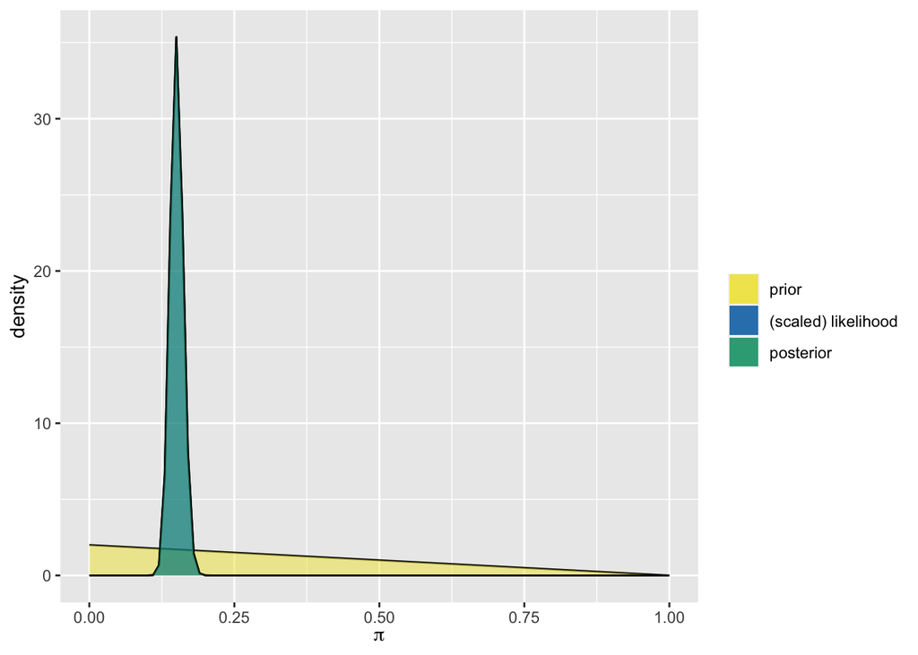

```r
#finding posterior model of beta
plot_beta_binomial(alpha = 1, beta = 2, y = 150, n = 1000)
```

```r
summarize_beta_binomial(alpha = 1, beta = 2, y =150, n = 1000)
```

```
##       model alpha beta      mean      mode          var         sd
## 1     prior     1    2 0.3333333 0.0000000 0.0555555556 0.23570226
## 2 posterior   151  852 0.1505484 0.1498501 0.0001273741 0.01128601
```

Posterior is Beta(151, 852)

```r
#finding middle 95% posterior credible interval
# 0.025th & 0.975th quantiles of the Beta(151,852) posterior
qbeta(c(0.025, 0.975), 151, 852)
```

```
## [1] 0.1291000 0.1733164
```

There is a 95% posterior probability that somewhere between 12.91% and 17.33% of people don’t believe in climate change.

## Exercise 8.15

1. Based on the credible interval I would say that Ha: pi > 0.1 is more likely.

```r
post_probc <- pbeta(0.10, 151,852) #post_probc of pi being less than 0.1
post_probcc <- 1-post_probc #doing the complement to find prob of pi being greather than .1
```

This can be interpreted as there’s roughly 99.99% posterior chance that the probability is *above* 0.10.

3. Calculate and interpret bayes factor.

```r
post_oddc <- post_probcc/(1-post_probcc) #finding posterior odds
post_oddc
```

```
## [1] 3197444
```

Next find prior odds

```r
prior_prob <- pbeta(.1, 1, 2)
prior_probc <- 1-prior_prob
prior_probc
```

```
## [1] 0.81
```

```r
prior_oddc <- prior_probc/(1-prior_probc)
prior_oddc
```

```
## [1] 4.263158
```

```r
BFc <- post_oddc/prior_oddc
BFc
```

```
## [1] 750017.6
```

4. The Bayes Factor is 750017.6 which means posterior odds of our alternate hypothesis are about 750017.6 times higher than the prior odds, therefore our confidence in the alternate hypothesis (pi is greater than .1) increased.

#Corrected

## Exercise 8.16

```r
# define the model; this is set of instructions (could've written this in notepad) that will pass to stan through r
climate_model <- "
  data {
    int<lower = 0, upper = 1000> Y;
  }
  parameters {
    real<lower = 0, upper = 1> pi;
  }
  model {
    Y ~ binomial(1000, pi);
    pi ~ beta(1, 2);
  }
"

# simulate the posterior
climate_sim <- stan(model_code = climate_model, data = list(Y = 150),
                chains = 4, iter = 5000*2, seed = 80)
```

```
## Trying to compile a simple C file
```

[output not shown]

2. Produce and discuss trace plots, overlaid desnity plots, and autocorrelation plots.

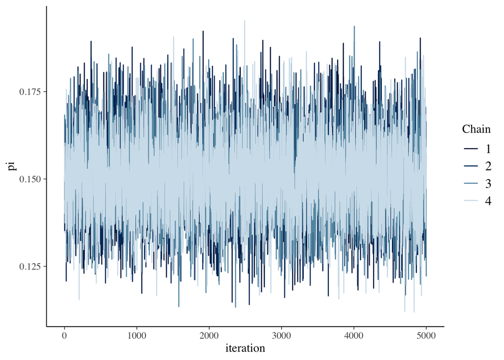

```r
# Parallel trace plots & density plots
mcmc_trace(climate_sim, pars = "pi", size = 0.5) +
  xlab("iteration")
```

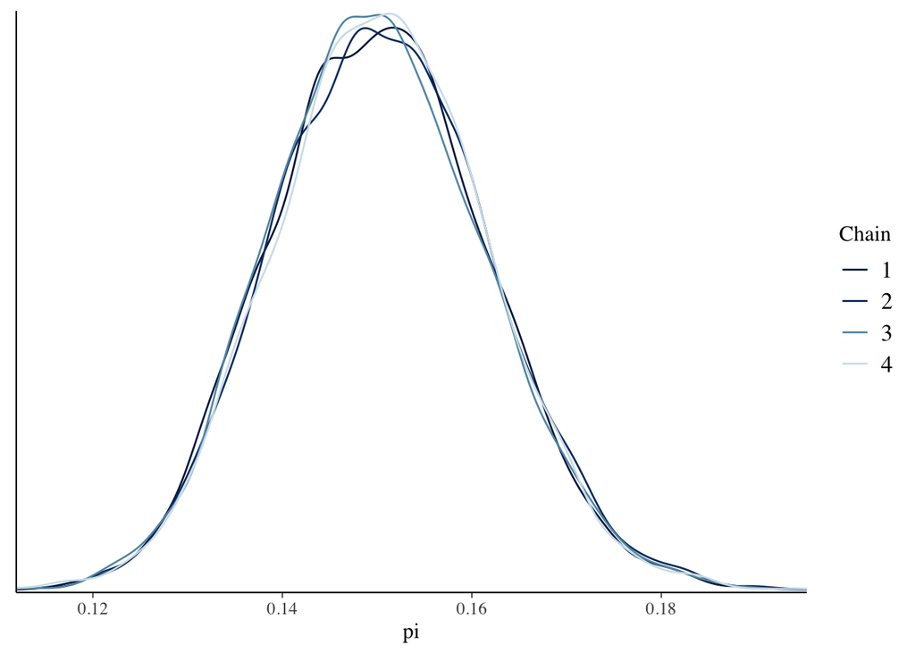

```r
mcmc_dens_overlay(climate_sim, pars = "pi")
```

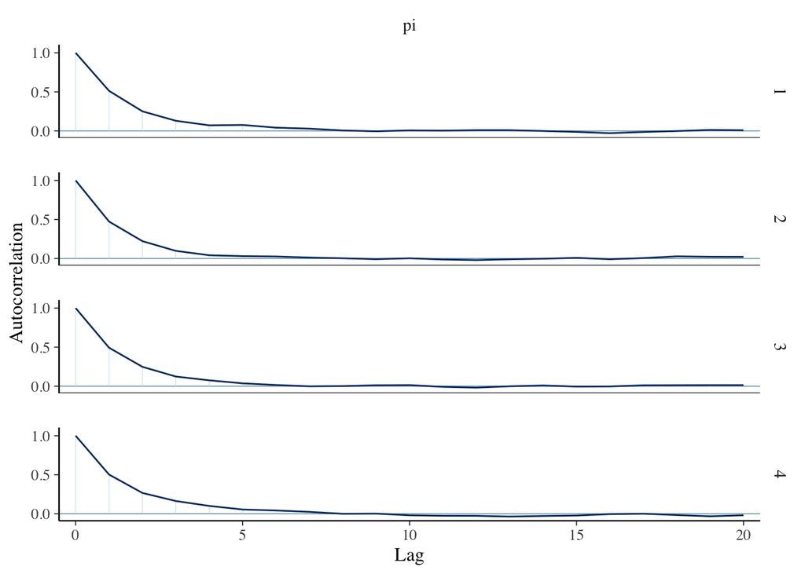

```r
# Autocorrelation plot
mcmc_acf(climate_sim, pars = "pi")
```

The MCMC trace plot looks appropriate (like a fuzzy caterpillar so it is stable) and pi is between 12.5% and 17.5%.The density plot shows a peak somewhere between 0.14 and 0.16. The autocorrelation plots show agreement among the four chains.

```r
# Markov chain diagnostics
rhat(climate_sim, pars = "pi")
```

```
## [1] 1.000703
```

```r
neff_ratio(climate_sim, pars = "pi")
```

```
## [1] 0.3237526
```

Rhat of 1 means that the simulation is extremely stable. If we multiply the neff by 20000 we get 6475.052 so this simulation is as effective as 6475 independent samples.

```r
  0.3237526*20000 #multiplying by 20000 because four Markov chains each with 5000 iterations
```

```
## [1] 6475.052
```

# Corrected

## Exercise 8.17

1. Use MCMC simulation to approximate a middle 95% posterior credible interval for pi using tidy.

```r
# MCMC posterior approximation; corrected to use direct calculation andd tidy()

tidy(climate_sim, conf.int = TRUE, conf.level = 0.95)
```

```
## # A tibble: 1 × 5
##   term  estimate std.error conf.low conf.high
##   <chr>    <dbl>     <dbl>    <dbl>     <dbl>
## 1 pi       0.150    0.0113    0.129     0.173
```

```r
#direct calculation
climate_chains_df <- as.data.frame(climate_sim, pars = "lp__", include = FALSE)
dim(climate_chains_df) #creating dataframe
```

```
## [1] 20000     1
```

```r
climate_chains_df |> #direct calculation
  summarize(
    low = quantile(pi, 0,25),
    up = quantile(pi, 0.975),
  )
```

```
##         low        up
## 1 0.1119126 0.1729132
```

```r
tidy(climate_sim, conf.int = TRUE, conf.level = 0.95) # A tibble: 1 × 5
```

```
## # A tibble: 1 × 5
##   term  estimate std.error conf.low conf.high
##   <chr>    <dbl>     <dbl>    <dbl>     <dbl>
## 1 pi       0.150    0.0113    0.129     0.173
```

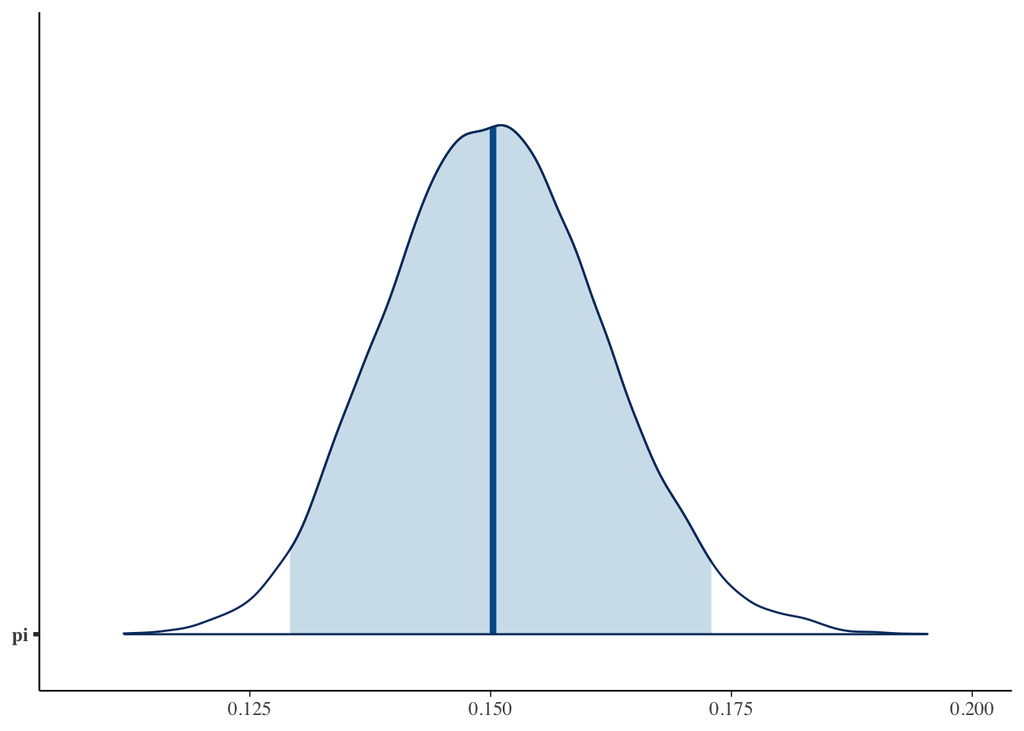

```r
mcmc_areas(climate_sim, pars = "pi", prob = 0.95) #shade 95% a visual complement to the mcm estimate
```

2. approximate posterior that probability that pi > 0.10

```r
# store 4 chains in a data frame
climate_chains_df <- as.data.frame(climate_sim, pars = "lp__", include = FALSE)
dim(climate_chains_df)
```

```
## [1] 20000     1
```

```r
# posterior summaries of pi
climate_chains_df |>
  summarize(post_mean = mean(pi),
            post_median = median(pi),
            post_mode = sample_mode(pi),
            lower_95 = quantile(pi, 0.025),
            upper_95 = quantile(pi, 0.975))
```

```
##   post_mean post_median post_mode  lower_95  upper_95
## 1 0.1503989   0.1502342  0.151024 0.1291653 0.1729132
```

```r
climate_chains_df |>
  mutate(above = pi > 0.10) |> #pi values that are above 0.10
  tabyl(above)
```

```
##  above     n percent
##   TRUE 20000       1
```

```r
climate_chains_df |>
  mutate(below = pi < .10) |>
  tabyl(below)
```

```
##  below     n percent
##  FALSE 20000       1
```

```r
#interesting to see how tabyl returned the same percent of above and below .1

climate_chains_df |>
  mutate(equal = pi > .12) |> #checked the approximate .95s CI values which makes more confident about my MCMC simulation
  tabyl(equal)
```

```
##  equal     n percent
##  FALSE    40   0.002
##   TRUE 19960   0.998
```

```r
climate_chains_df |>
  mutate(equals = pi < .17) |>
  tabyl(equals)
```

```
##  equals     n percent
##   FALSE   881 0.04405
##    TRUE 19119 0.95595
```

3. The approximations in part a and b shows a post mode and mean of about 0.15. The exact posterior mean found in 8.14 is about 0.15 so the approximation is very close to the actual. The confidence intervals are also very similar to each other (they mostly differ on third decimal).

#Corrected

## Exercise 8.18

```r
# Set the seed
set.seed(100)

# Predict a value of Y' for each pi value in the chain
climate_chains_df <- climate_chains_df |>
  mutate(y_predict = rbinom(length(pi), size = 100, prob = pi))

# looking at the chains
climate_chains_df |>
  head(5)
```

```
##          pi y_predict
## 1 0.1504052        13
## 2 0.1481624        12
## 3 0.1504986        15
## 4 0.1475372         9
## 5 0.1516831        15
```

Histogram of the model

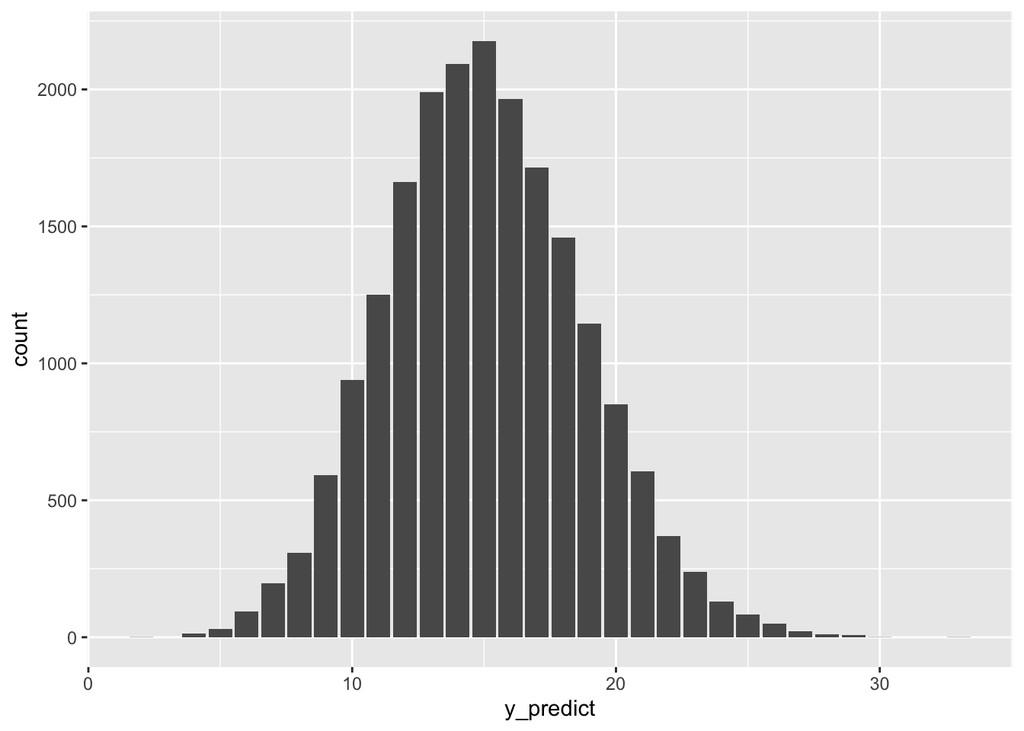

```r
# Plot the 20,000 predictions
ggplot(climate_chains_df, aes(x = y_predict)) +
  stat_count()
```

```r
climate_chains_df |>
  summarize(mean = mean(y_predict),
            lower_80 = quantile(y_predict, 0.1),
            upper_80 = quantile(y_predict, 0.9))
```

```
##       mean lower_80 upper_80
## 1 15.02805       10       20
```

3. There’s an 80% chance that Y’ is between 10 and 20.

```r
climate_chains_df |>
  mutate(is = y_predict >= 20) |> #correction: using tabyl to find pi of Y = 20
  tabyl(is)
```

```
##     is     n percent
##  FALSE 17628  0.8814
##   TRUE  2372  0.1186
```

This shows that there’s an .118 change that Y is greater than or equal to 20.

# Corrected

## Exercise 8.19

1. The normal-normal is appropriate since we want to know the central tendency of a series of Y values.
2. My prior understanding is that mu is 200mm. We’re given a range of 140 and 260 to use to find stdev.

```r
p <- c(140,142, 145, 150, 155, 157, 158, 175, 177, 180, 182, 270, 276, 260)
sd(p) #standard deviation is several random values to estimate
```

```
## [1] 48.3602
```

Prior normal is N(200,48); though 48 seems high probably because I only used 14 values to estimate this sd.

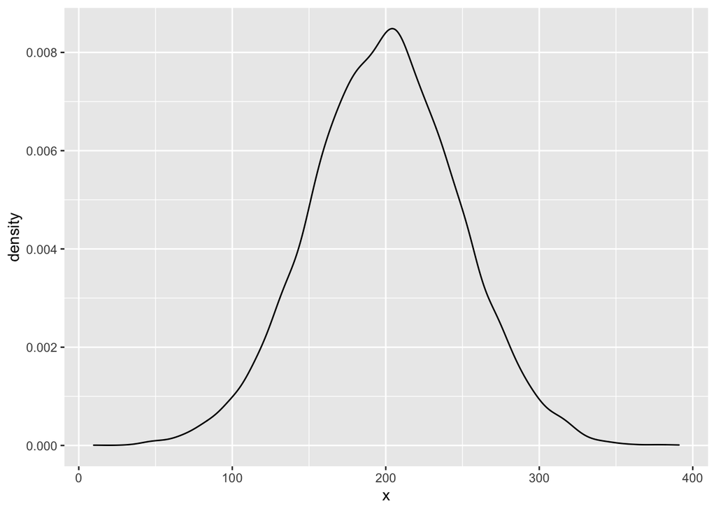

```r
#plotting this distribution
data.frame(x = rnorm(10000, #dataframe with 1 column x and 10,000 pulls
                     mean = 200,
                     sd = 48)) |>
             ggplot(aes(x =x )) +
             geom_density() #good tool for checking priors
```

3. With help from Braulio, found the number of Adelie penguins their mean height and true sd.

```r
penguins_bayes |> filter(species=="Adelie") |>
  summarize(pen=n(), mean=mean(flipper_length_mm, na.rm=TRUE), sd=sd(flipper_length_mm, na.rm=TRUE)) #this is likelihood (what's observed in the data); prior is not affecting this at this state
```

```
## # A tibble: 1 × 3
##     pen  mean    sd
##   <int> <dbl> <dbl>
## 1   152  190.  6.54
```

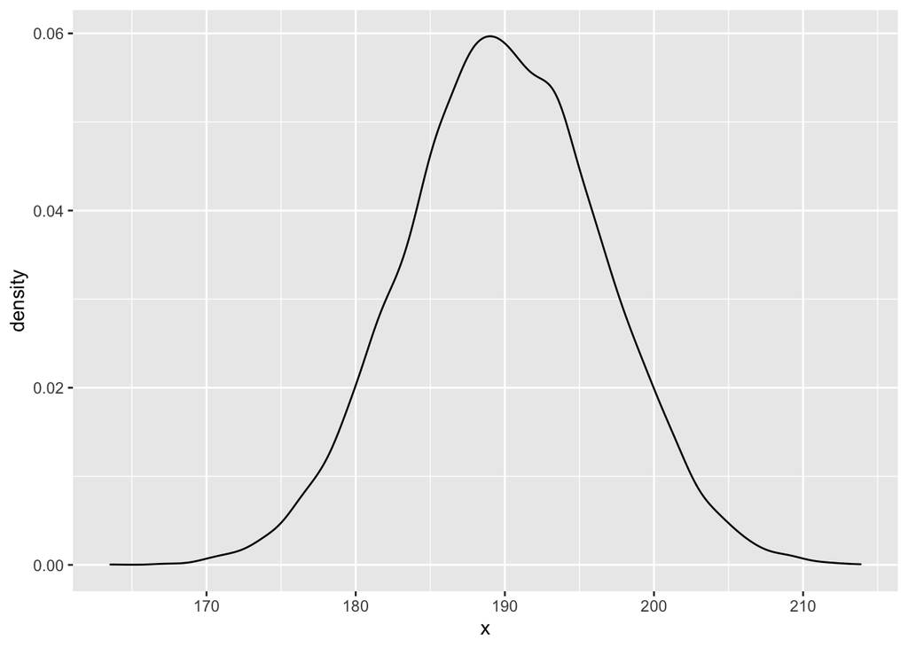

```r
data.frame(x = rnorm(10000, #dataframe with 1 column x and 10,000 pulls
                     mean = 189.9536,
                     sd = 6.539457)) |>
             ggplot(aes(x =x )) +
             geom_density() #notice that this is narrower and center is lower than prior estimate
```

```r
qnorm(c(0.025, 0.975), 189.9536, 6.539457) #this is just the 95% CI for the liklihood; notice that you haven't used data in this qnorm
```

```
## [1] 177.1365 202.7707
```

```r
summarize_normal_normal(mean = 200, #prior center of mass
                        sd = 48, #prior stdev
                        sigma = 6.53, #data has sigma of 6.53
                        y_bar = 189, #data had this mu
                        n = 152) #sample size; #variance is small because we're estimating credible interval of mu; not of the flipper lengths; this is dist. of possible mu
```

```
##       model     mean     mode          var         sd
## 1     prior 200.0000 200.0000 2304.0000000 48.0000000
## 2 posterior 189.0013 189.0013    0.2804981  0.5296207
```

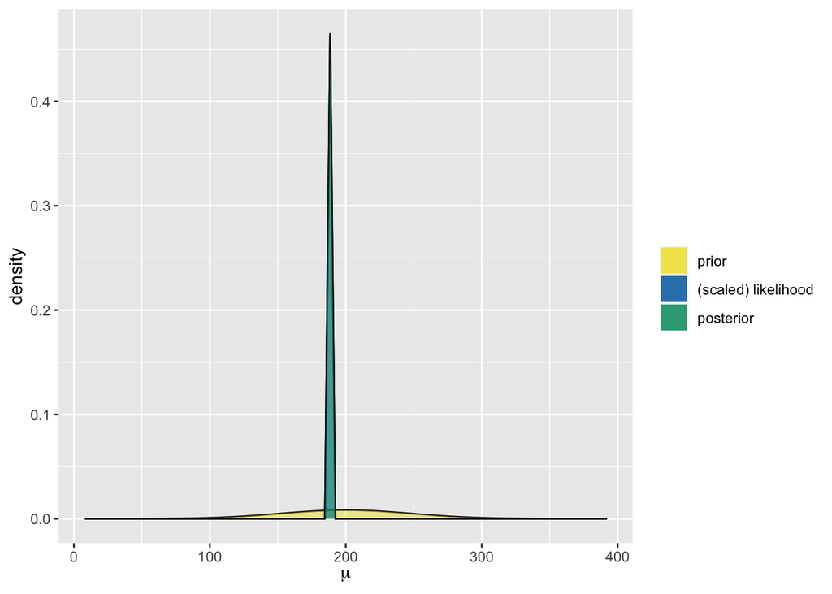

```r
plot_normal_normal(mean = 200, #prior center of mass
                        sd = 48, #prior stdev
                        sigma = 6.53, #data has sigma of 6.53
                        y_bar = 189, #data had mu
                        n = 152) #we're estimating one parameter mu; notice x-axis
```

```r
qnorm(c(0.025, 0.975), 189.0013, 0.5296207)
```

```
## [1] 187.9633 190.0393
```

There is a 95% posterior chance that the mean is between 187.96 and 190.0393.

# Corrected

## Exercise 8.20

1. Write a 2 sided hypothesis test H0: mu < 200 Ha: 200 < mu < 220
2. I would say that I would fail to reject the null hypothesis based on the credible interval from 8.19 which was between 187.96 and 190.0393; this strongly suggests that mu will not exceed 200.

```r
pen_model <- "
data {
    vector[146] Y;
}
parameters {
    real mu;
}
model {
   Y ~ normal(mu, 6.5);
   mu ~ normal(200,7 );
}
"
d <- list(Y = penguins_bayes |> #making a list
  filter(species == "Adelie") |> drop_na() |> #filtering for Adelie species
  pull(flipper_length_mm)) #we're just interested in vector of flipper lengths

pen_sim <- stan(model_code = pen_model, data = d, chains = 4, iter = 5000)
```

```
## Trying to compile a simple C file
```

[output not shown]

## Exercise 8.21

```r
view(loons)
```

3. There are 18 data points. The average loon count is 1.5.

```r
x <- c(0, 5, 0, 0, 0, 2, 0, 2, 1, 1, 0, 4, 2, 0, 3, 3, 1, 3) #create vector
result.mean <- mean(x) #find mean
print(result.mean) #viewing results. This section of code was inspired by https://www.tutorialspoint.com/r/r_mean_median_mode.htm
```

```
## [1] 1.5
```

4. Find middle 95% posterior credible interval for lambda.

```r
# 0.025th & 0.975th quantiles of the Gamma(18,92) posterior
qgamma(c(0.025, 0.975), 1, 1.5) #used average rate from part c for rate.
```

```
## [1] 0.01687854 2.45925297
```

## Exercise 8.22

1. The hypotheses are H0: lambda is greater than or equal to 1 and Ha: lambda <1
2. Based on the credible interval from 8.21 and the data, I would expect the that both H0 and Ha are plausible and would need more testing to be decisive.

```r
qgamma(c(0.025, 0.975), 1, 1.5)
```

```
## [1] 0.01687854 2.45925297
```

4. I would interpret this as most lambda values are between 0 and 3.

## Exercise 8.23

```r
# Step 1: Define  the model
loongamma_model <- "
  data {
    int<lower = 0> Y[18];
  }
  parameters {
    real<lower = 0> lambda;
  }
  model {
    Y ~ poisson(lambda);
    lambda ~ gamma(1, 1.5);
  }
  "
# Step 2: simulate the posterior
loon_sim <- stan(model_code = loongamma_model, data = list(Y = c(0, 5, 0, 0, 0, 2, 0, 2, 1, 1, 0, 4, 2, 0, 3, 3, 1, 3)),
               chains = 4, iter = 5000*2, seed = 500)
```

```
## Trying to compile a simple C file
```

[output not shown]

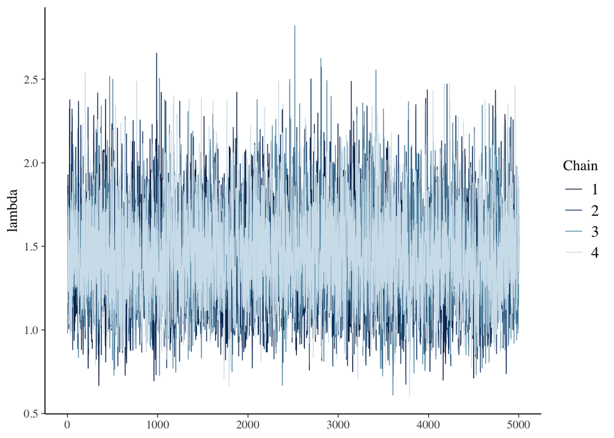

```r
#trace and density plots
mcmc_trace(loon_sim, pars = "lambda", size = 0.3)
```

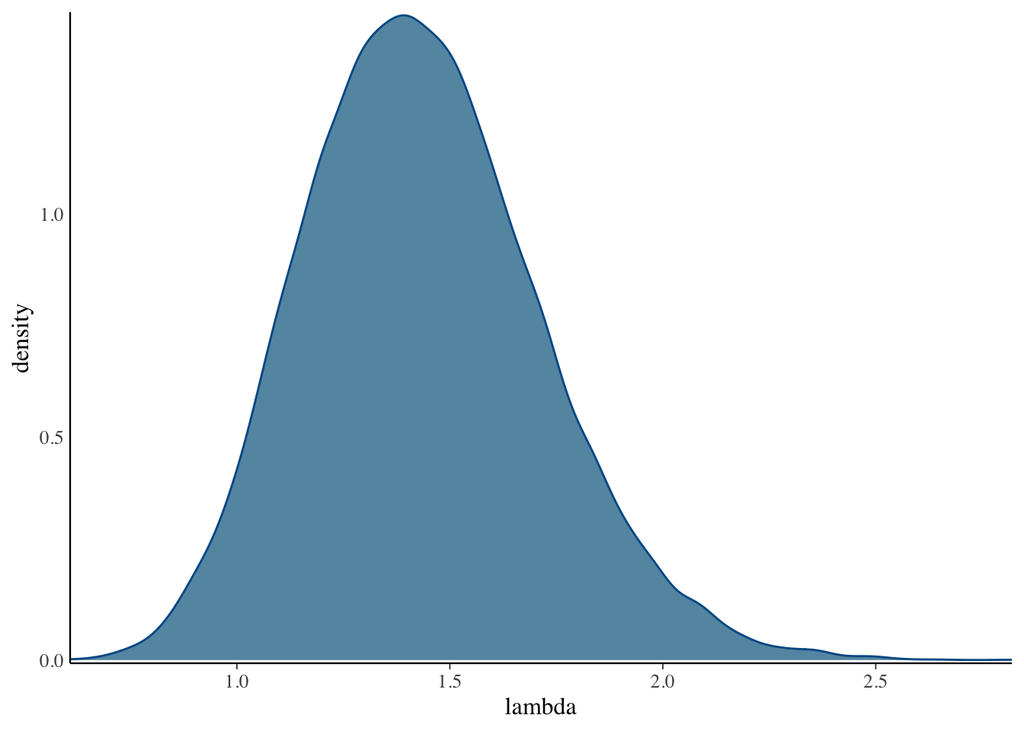

```r
mcmc_dens(loon_sim, pars = "lambda") +
  yaxis_text(TRUE) +
  ylab("density")
```

4. Based on the simulation, the MCMC looks stable.

## Exercise 8.24

```r
## still need to correct this one.
# store 4 chains in a data frame

loons_chains_df <- as.data.frame(loon_sim, pars = "lp__", include = FALSE)
dim(loons_chains_df)
```

```
## [1] 20000     1
```

```r
# Set the seed
set.seed(100)



# looking at the chains
loons_chains_df |>
  head(5)
```

```
##     lambda
## 1 1.862908
## 2 1.862908
## 3 1.853179
## 4 1.679659
## 5 1.927435
```

```r
## This set of code isn't working and had trouble with 8.19 - 8.24.
```